# Pesquisa reproduzível

05.out.2020

## Nunca esqueça

## Pacotes e diretório de trabalho

```r
lista.de.pacotes = c("tidyverse","haven","lubridate","janitor","readxl",
                     "stringr", "magrittr") # escreva a lista de pacotes

novos.pacotes <- lista.de.pacotes[!(lista.de.pacotes %in%
                                      installed.packages()[,"Package"])]
if(length(novos.pacotes) > 0) {install.packages(novos.pacotes)}
lapply(lista.de.pacotes, require, character.only=T)
#rm(lista.de.pacotes,novos.pacotes)
rm(list = ls())
gc()



# Definiindo o diretorio de trabalho como do arquivo local
setwd(dirname(rstudioapi::getActiveDocumentContext()$path))

setwd("/Volumes/Macintosh HD/MQCP_IPOL_2020/Slides/aula 04") # mmudando meu direto
```

## O Universo tidyverse

## Manifesto tidyverse

- Reutilizar estruturas de dados existentes.
- Organizar funções simples usando o pipe.
- Aderir à programação funcional.
- Projetado para ser usado por seres humanos.

## Manifesto tidy

- Tidy Tools Manifesto https://cran.r-project.org/web/packages/tidyverse/vignettes/manifesto.html
- Tidy data vignette https://cran.r-project.org/web/packages/tidyr/vignettes/tidy-data.html
- Tidy Data paper http://vita.had.co.nz/papers/tidy-data.pdf
- Conjunto de pacotes https://www.tidyverse.org/packages/

## Conjunto de dados

Vamos trabalhar com a base `decisoes`, que contém decisões do Tribunal de Justiça de São Paulo

```r
decisoes <- read_rds("dados/decisoes.rds") %>%
  janitor::clean_names() # com dois pontos eu não preciso usar library
glimpse(decisoes)
```

```
## Rows: 11,731
## Columns: 9
## $ id_decisao     <chr> "11094999", "11093733", "11093677", "11093270", "11093…
## $ n_processo     <chr> "0057003-20.2017.8.26.0000", "0052762-03.2017.8.26.000…
## $ classe_assunto <chr> "Habeas Corpus / Homicídio Simples", "Habeas Corpus / …
## $ municipio      <chr> "Cosmópolis", "São Paulo", "Ribeirão Preto", "Araçatub…
## $ camara         <chr> "3ª Câmara de Direito Criminal", "3ª Câmara de Direito…
## $ data_decisao   <chr> "19/12/2017", "19/12/2017", "19/12/2017", "14/12/2017"…
## $ data_registro  <chr> "19/12/2017", "19/12/2017", "19/12/2017", "19/12/2017"…
## $ juiz           <chr> "Luiz Antonio Cardoso", "Luiz Antonio Cardoso", "Luiz …
## $ txt_decisao    <chr> NA, NA, NA, "Execução Penal –  Comutação de Penas –  D…
```

## Características do `dplyr`

- A utilização é facilitada com o emprego do operador `%>%`
- No primeiro argumento colocamos o `data.frame` ou o `tibble`, e nos outros argumentos colocamos o que queremos fazer.

## As cinco funções principais do `dplyr`

- `select`: selecionar colunas
- `filter`: filtrar linhas
- `mutate`: criar colunas
- `summarise`: sumarizar colunas
- `arrange`: ordenar linhas

## tydyr

## Alterando o formato de dados

Até agora, estudamos os principais ferramentas de transformação de dados do `dplyr`. Agora vamos aumentar nossa caixa-de-ferramentas com `tidyr`

- Carregando uma nova base de dados, que completa a de decisões.

```r
processos <- read_rds("dados/processos_nested.rds")
```

## Fomato tidy

- Hadley Wickham http://r4ds.had.co.nz/tidy-data.html

## Funções do pacote

- Enquanto o `dplyr` faz recortes na base (com `filter()`e `select()`) e adições simples (`mutate()`, `summarise()`), o `tidyr` mexe no **formato** da tabela (`gather()`, `spread()`) e faz modificações menos triviais.
- As funções do `tidyr` geralmente vêm em pares com seus inversos:
  - `gather()` e `spread()`, -> substituídas por `pivot_longer` e `pivot_wider`
  - `nest()` e `unnest()`,
  - `separate()` e `unite()`

## Onde estamos

http://r4ds.had.co.nz/wrangle-intro.html

## `gather()`

- `gather()` empilha o banco de dados
- `pivot_longer` empilha de um jeito ainda mais fácil

```r
decisoes %>%
  filter(!is.na(id_decisao)) %>%
  select(id_decisao:data_registro) %>%
  # 1. nome da coluna que vai guardar os nomes de colunas empilhadas
  # 2. nome da coluna que vai guardar os valores das colunas
  # 3. seleção das colunas a serem empilhadas
  gather(key="variavel", value="valor", -id_decisao) %>%
  arrange(id_decisao)
```

```
## # A tibble: 69,996 x 3
##    id_decisao variavel       valor
##    <chr>      <chr>          <chr>
##  1 11026431   n_processo     0000009-51.2015.8.26.0546
##  2 11026431   classe_assunto Apelação / Tráfico de Drogas e Condutas Afins
##  3 11026431   municipio      Itapira
##  4 11026431   camara         5ª Câmara de Direito Criminal
##  5 11026431   data_decisao   30/11/2017
##  6 11026431   data_registro  01/12/2017
##  7 11026432   n_processo     0002267-69.2013.8.26.0654
##  8 11026432   classe_assunto Apelação / Furto Qualificado
##  9 11026432   municipio      Vargem Grande Paulista
## 10 11026432   camara         5ª Câmara de Direito Criminal
## # … with 69,986 more rows
```

## `pivot_longer`

Base `relig_income` do `tidyr` 3 variáveis:

- religion, nas linhas
- income, nas colunas e
- count, nas células

```r
tidyr::relig_income
```

```
## # A tibble: 18 x 11
##    religion `<$10k` `$10-20k` `$20-30k` `$30-40k` `$40-50k` `$50-75k` `$75-100k`
##    <chr>      <dbl>     <dbl>     <dbl>     <dbl>     <dbl>     <dbl>      <dbl>
##  1 Agnostic      27        34        60        81        76       137        122
##  2 Atheist       12        27        37        52        35        70         73
##  3 Buddhist      27        21        30        34        33        58         62
##  4 Catholic     418       617       732       670       638      1116        949
##  5 Don’t k…      15        14        15        11        10        35         21
##  6 Evangel…     575       869      1064       982       881      1486        949
##  7 Hindu          1         9         7         9        11        34         47
##  8 Histori…     228       244       236       238       197       223        131
##  9 Jehovah…      20        27        24        24        21        30         15
## 10 Jewish        19        19        25        25        30        95         69
## 11 Mainlin…     289       495       619       655       651      1107        939
## 12 Mormon        29        40        48        51        56       112         85
## 13 Muslim         6         7         9        10         9        23         16
## 14 Orthodox      13        17        23        32        32        47         38
## 15 Other C…       9         7        11        13        13        14         18
## 16 Other F…      20        33        40        46        49        63         46
## 17 Other W…       5         2         3         4         2         7          3
## 18 Unaffil…     217       299       374       365       341       528        407
## # … with 3 more variables: `$100-150k` <dbl>, `>150k` <dbl>, `Don't
## #   know/refused` <dbl>
```

```r
tidyr::relig_income %>%
  pivot_longer(!religion,
               names_to = "income", # diz a varável onde entrarão os nomes
               values_to = "count" # diz a variável onde entrarão os valores
               )
```

```
## # A tibble: 180 x 3
##    religion income             count
##    <chr>    <chr>              <dbl>
##  1 Agnostic <$10k                 27
##  2 Agnostic $10-20k               34
##  3 Agnostic $20-30k               60
##  4 Agnostic $30-40k               81
##  5 Agnostic $40-50k               76
##  6 Agnostic $50-75k              137
##  7 Agnostic $75-100k             122
##  8 Agnostic $100-150k            109
##  9 Agnostic >150k                 84
## 10 Agnostic Don't know/refused    96
## # … with 170 more rows
```

## `spread()`

- `spread()` espalha uma variável nas colunas e preenche com outra variável
- Função inversa de `gather`
- Bem mais fácil com `pivot_wider`

```r
decisoes %>%
  filter(!is.na(id_decisao)) %>%
  select(id_decisao:data_registro) %>%
  gather(key, value, -id_decisao) %>%
  # 1. coluna a ser espalhada
  # 2. valores da coluna
  spread(key, value)
```

```
## # A tibble: 11,666 x 7
##    id_decisao camara classe_assunto data_decisao data_registro municipio
##    <chr>      <chr>  <chr>          <chr>        <chr>         <chr>
##  1 11026431   5ª Câ… Apelação / Tr… 30/11/2017   01/12/2017    Itapira
##  2 11026432   5ª Câ… Apelação / Fu… 30/11/2017   01/12/2017    Vargem G…
##  3 11026433   5ª Câ… Apelação / Ro… 30/11/2017   01/12/2017    Sertãozi…
##  4 11026434   12ª C… Agravo de Exe… 18/10/2017   01/12/2017    Ribeirão…
##  5 11026435   15ª C… Apelação / Tr… 30/11/2017   01/12/2017    São Paulo
##  6 11026442   5ª Câ… Apelação / Es… 30/11/2017   01/12/2017    Jales
##  7 11026445   13ª C… Apelação / Us… 30/11/2017   01/12/2017    Santa Fé…
##  8 11026453   5ª Câ… Apelação / Cr… 30/11/2017   01/12/2017    Franca
##  9 11026455   12ª C… Apelação / Ro… 05/07/2017   01/12/2017    Franca
## 10 11026456   12ª C… Apelação / Ro… 03/05/2017   01/12/2017    São José…
## # … with 11,656 more rows, and 1 more variable: n_processo <chr>
```

## `pivot_wider`

```r
decisoes %>%
  filter(!is.na(id_decisao)) %>%
  select(id_decisao:data_registro) %>%
  pivot_longer(!id_decisao,
               names_to = "tipo", # diz a varável onde entrarão os nomes
               values_to = "info" # diz a variável onde entrarão os valores
               ) %>%
  # 1. coluna a ser espalhada
  # 2. valores da coluna
  pivot_wider(names_from = "tipo",
              values_from = "info")
```

```
## # A tibble: 11,666 x 7
##    id_decisao n_processo classe_assunto municipio camara data_decisao
##    <chr>      <chr>      <chr>          <chr>     <chr>  <chr>
##  1 11094999   0057003-2… Habeas Corpus… Cosmópol… 3ª Câ… 19/12/2017
##  2 11093733   0052762-0… Habeas Corpus… São Paulo 3ª Câ… 19/12/2017
##  3 11093677   0055169-7… Habeas Corpus… Ribeirão… 3ª Câ… 19/12/2017
##  4 11093270   9000580-8… Agravo de Exe… Araçatuba 8ª Câ… 14/12/2017
##  5 11093374   0052938-7… Mandado de Se… São Paulo 8ª Câ… 14/12/2017
##  6 11093320   9000723-7… Agravo de Exe… Presiden… 8ª Câ… 14/12/2017
##  7 11091506   0003276-8… Apelação / Tr… Bertioga  8ª Câ… 14/12/2017
##  8 11093326   9000298-1… Agravo de Exe… Taubaté   8ª Câ… 14/12/2017
##  9 11092475   0004653-3… Apelação / Tr… Aparecida 8ª Câ… 14/12/2017
## 10 11093773   2221930-6… Habeas Corpus… Jandira   3ª Câ… 19/12/2017
## # … with 11,656 more rows, and 1 more variable: data_registro <chr>
```

- Qual juiz julga a maior proporção de processos que tratam de drogas

– Dica: construa um `data.frame` contendo as colunas juiz, n_processos_drogas, n_processos_n_drogas e total_processos, remodelando os dados para haver um juiz por linha e utilizando `spread()`

## Resolução

[output not shown]

- Qual quantidade mensal de decisões por juiz?
- Dica: use `data_decisao` `dmy()` e `month()`

```r
decisoes %>%
  filter(!is.na(txt_decisao)) %>%
  mutate(txt_decisao = tolower(txt_decisao),
         droga = str_detect(txt_decisao,
    "droga|entorpecente|psicotr[óo]pico|maconha|haxixe|coca[íi]na"),
    droga=case_when(
      droga==TRUE ~ "droga",
      droga==FALSE ~ "n_droga"
    )) %>%
  group_by(juiz,droga) %>%
  summarise(n=n()) %>%
  spread(droga,n,fill = 0) %>%
  mutate(total=droga+n_droga,
         proporcao=droga/total)
```

## Resultado

```
## # A tibble: 65 x 5
## # Groups:   juiz [65]
##    juiz                   droga n_droga total proporcao
##    <chr>                  <dbl>   <dbl> <dbl>     <dbl>
##  1 Airton Vieira             23     131   154     0.149
##  2 Alcides Malossi Junior    23      72    95     0.242
##  3 Alexandre Almeida         41     122   163     0.252
##  4 Amaro Thomé               36      96   132     0.273
##  5 Andrade Sampaio           35      79   114     0.307
##  6 Angélica de Almeida        2       6     8     0.25
##  7 Antonio Tadeu Ottoni       0       1     1     0
##  8 Bandeira Lins              0       2     2     0
##  9 Camargo Aranha Filho      32     109   141     0.227
## 10 Camilo Léllis             32     133   165     0.194
## # … with 55 more rows
```

## Exemplo para o ggplot

## Unindo e separando colunas

- `unite` junta duas ou mais colunas usando algum separador (`_`, por exemplo).
- `separate` faz o inverso de `unite`, e uma coluna em várias usando um separador.

## Exemplo de separação de colunas

- Olhe os valores da variável classe_assunto

## Exemplo de separação de colunas

- Vamos separar a coluna classe_assunto em duas colunas
- coluna classe e coluna assunto
- Existe separador? -> sim, `/`
- Usei count apenas em assunto

## Em ação

```r
decisoes %>%
  select(n_processo, classe_assunto) %>%
  separate(classe_assunto, c('classe', 'assunto'), sep = ' / ',
           extra = 'merge', fill = 'right') %>%
  count(assunto, sort = TRUE)

## count é um jeito resumido de usar group_by() %>% summarise(n())
```

## Em ação

```
## # A tibble: 152 x 2
##    assunto                                n
##    <chr>                              <int>
##  1 Tráfico de Drogas e Condutas Afins  2441
##  2 Pena Privativa de Liberdade         1106
##  3 Roubo Majorado                      1093
##  4 Furto Qualificado                    838
##  5 Roubo                                780
##  6 Progressão de Regime                 607
##  7 Furto                                450
##  8 Receptação                           353
##  9 Homicídio Qualificado                329
## 10 Crimes de Trânsito                   322
## # … with 142 more rows
```

## List columns: `nest()` e `unnest()`

`nest()` e `unnest()` são operações inversas e servem para tratar dados complexos, como o que temos em `processos`

```r
d_partes <- processos %>%
  select(n_processo, partes) %>%
  unnest(partes)
```

As list columns são uma forma condensada de guardar dados que estariam em múltiplas tabelas. Por exemplo, uma alternativa à colocar as `partes` numa list column seria guardar a tabela `d_partes` separadamente.

```r
glimpse(d_partes)
```

```
## Rows: 37,579
## Columns: 5
## $ n_processo <chr> "0000003-71.2016.8.26.0073", "0000003-71.2016.8.26.0073", …
## $ id         <int> 1, 1, 2, 1, 1, 2, 1, 1, 2, 1, 1, 2, 1, 1, 2, 1, 1, 2, 1, 1…
## $ name       <chr> "JOSE MARIA JUSTINO NETO", "Defensoria Pública do Estado d…
## $ part       <chr> "Apelante", "Apelante", "Apelado", "Apelante", "Apelante",…
## $ role       <chr> "Apelante", "Apelante", "Apelado", "Apelante", "Advogado",…
```

## Duplicatas

Para retirar duplicatas, utilizar `distinct`. Ele considera apenas a primeira linha em que encontra um padrão para as combinações de variáveis escolhidas e descarta as demais.

```r
decisoes %>%
  distinct(municipio)
```

```
## # A tibble: 315 x 1
##    municipio
##    <chr>
##  1 Cosmópolis
##  2 São Paulo
##  3 Ribeirão Preto
##  4 Araçatuba
##  5 Presidente Prudente
##  6 Bertioga
##  7 Taubaté
##  8 Aparecida
##  9 Jandira
## 10 Flórida Paulista
## # … with 305 more rows
```

## Por coluna

Para manter as demais colunas, use `.keep_all=`:

```r
decisoes %>%
  distinct(municipio, camara,
           .keep_all = TRUE)
```

```
## # A tibble: 2,760 x 9
##    id_decisao n_processo classe_assunto municipio camara data_decisao
##    <chr>      <chr>      <chr>          <chr>     <chr>  <chr>
##  1 11094999   0057003-2… Habeas Corpus… Cosmópol… 3ª Câ… 19/12/2017
##  2 11093733   0052762-0… Habeas Corpus… São Paulo 3ª Câ… 19/12/2017
##  3 11093677   0055169-7… Habeas Corpus… Ribeirão… 3ª Câ… 19/12/2017
##  4 11093270   9000580-8… Agravo de Exe… Araçatuba 8ª Câ… 14/12/2017
##  5 11093374   0052938-7… Mandado de Se… São Paulo 8ª Câ… 14/12/2017
##  6 11093320   9000723-7… Agravo de Exe… Presiden… 8ª Câ… 14/12/2017
##  7 11091506   0003276-8… Apelação / Tr… Bertioga  8ª Câ… 14/12/2017
##  8 11093326   9000298-1… Agravo de Exe… Taubaté   8ª Câ… 14/12/2017
##  9 11092475   0004653-3… Apelação / Tr… Aparecida 8ª Câ… 14/12/2017
## 10 11093773   2221930-6… Habeas Corpus… Jandira   3ª Câ… 19/12/2017
## # … with 2,750 more rows, and 3 more variables: data_registro <chr>,
## #   juiz <chr>, txt_decisao <chr>
```

## `janitor::get_dupes()`

Use `janitor::get_dupes()` para averiguar os casos em que há repetição de combinações de colunas.

```r
decisoes %>%
  get_dupes(n_processo)
```

```
## # A tibble: 114 x 10
##    n_processo dupe_count id_decisao classe_assunto municipio camara data_decisao
##    <chr>           <int> <chr>      <chr>          <chr>     <chr>  <chr>
##  1 0000276-8…          2 11051087   Apelação / Tr… Itaporan… 2ª Câ… 27/11/2017
##  2 0000276-8…          2 11093633   Embargos de D… Itaporan… 2ª Câ… 18/12/2017
##  3 0000358-1…          2 11108278   Embargos de D… São Paulo 2ª Câ… 15/01/2018
##  4 0000358-1…          2 11028129   Apelação / Ro… São Paulo 2ª Câ… 27/11/2017
##  5 0002236-1…          2 11041351   Apelação / Co… Nhandeara 1ª Câ… 27/11/2017
##  6 0002236-1…          2 11041352   Apelação / Co… Nhandeara 1ª Câ… 27/11/2017
##  7 0004453-2…          2 11041132   Apelação / Tr… São Paulo 2ª Câ… 13/11/2017
##  8 0004453-2…          2 11093635   Embargos de D… São Paulo 2ª Câ… 18/12/2017
##  9 0004636-5…          3 11032094   Apelação / Tr… Olímpia   2ª Câ… 27/11/2017
## 10 0004636-5…          3 11032093   Apelação / Tr… Olímpia   2ª Câ… 27/11/2017
## # … with 104 more rows, and 3 more variables: data_registro <chr>, juiz <chr>,
## #   txt_decisao <chr>
```

## Joins

## Dados relacionais

- Hadley Wickham http://r4ds.had.co.nz/relational-data.html

## Principais funções

Para juntar tabelas, usar `inner_join`, `left_join`, `anti_join`, etc.

## Visualizando

## Exemplo de inner join:

```r
decisoes %>%
  filter(data_registro == "18/01/2018", !is.na(id_decisao)) %>%
  select(id_decisao, n_processo) %>%
  inner_join(processos, "n_processo")
```

```
## # A tibble: 169 x 5
##    id_decisao n_processo             infos           partes        results
##    <chr>      <chr>                  <list>          <list>        <list>
##  1 11109089   0003779-93.2015.8.26.… <tibble [14 × … <tibble [3 ×… <tibble [1 ×…
##  2 11109088   3001293-25.2013.8.26.… <tibble [13 × … <tibble [3 ×… <tibble [1 ×…
##  3 11108246   0063566-45.2015.8.26.… <tibble [14 × … <tibble [3 ×… <tibble [1 ×…
##  4 11108245   0003528-84.2015.8.26.… <tibble [14 × … <tibble [3 ×… <tibble [1 ×…
##  5 11109087   0008470-76.2015.8.26.… <tibble [14 × … <tibble [4 ×… <tibble [1 ×…
##  6 11109086   0013767-62.2012.8.26.… <tibble [14 × … <tibble [4 ×… <tibble [1 ×…
##  7 11109085   3019561-54.2013.8.26.… <tibble [14 × … <tibble [3 ×… <tibble [1 ×…
##  8 11108348   0003072-91.2017.8.26.… <tibble [11 × … <tibble [3 ×… <tibble [1 ×…
##  9 11108725   0009578-41.2017.8.26.… <tibble [12 × … <tibble [4 ×… <tibble [1 ×…
## 10 11108347   3001116-52.2013.8.26.… <tibble [12 × … <tibble [3 ×… <tibble [1 ×…
## # … with 159 more rows
```

## Exemplo de right join:

```r
decisoes %>%
  filter(data_registro == "18/01/2018", !is.na(id_decisao)) %>%
  select(id_decisao, n_processo) %>%
  right_join(processos, "n_processo")
```

```
## # A tibble: 11,638 x 5
##    id_decisao n_processo             infos           partes        results
##    <chr>      <chr>                  <list>          <list>        <list>
##  1 11109089   0003779-93.2015.8.26.… <tibble [14 × … <tibble [3 ×… <tibble [1 ×…
##  2 11109088   3001293-25.2013.8.26.… <tibble [13 × … <tibble [3 ×… <tibble [1 ×…
##  3 11108246   0063566-45.2015.8.26.… <tibble [14 × … <tibble [3 ×… <tibble [1 ×…
##  4 11108245   0003528-84.2015.8.26.… <tibble [14 × … <tibble [3 ×… <tibble [1 ×…
##  5 11109087   0008470-76.2015.8.26.… <tibble [14 × … <tibble [4 ×… <tibble [1 ×…
##  6 11109086   0013767-62.2012.8.26.… <tibble [14 × … <tibble [4 ×… <tibble [1 ×…
##  7 11109085   3019561-54.2013.8.26.… <tibble [14 × … <tibble [3 ×… <tibble [1 ×…
##  8 11108348   0003072-91.2017.8.26.… <tibble [11 × … <tibble [3 ×… <tibble [1 ×…
##  9 11108725   0009578-41.2017.8.26.… <tibble [12 × … <tibble [4 ×… <tibble [1 ×…
## 10 11108347   3001116-52.2013.8.26.… <tibble [12 × … <tibble [3 ×… <tibble [1 ×…
## # … with 11,628 more rows
```

## Limpeza

## Duplicatas

Para retirar duplicatas, utilizar `distinct`. Ele considera apenas a primeira linha em que encontra um padrão para as combinações de variáveis escolhidas e descarta as demais.

```r
decisoes %>%
  distinct(municipio)
```

```
## # A tibble: 315 x 1
##    municipio
##    <chr>
##  1 Cosmópolis
##  2 São Paulo
##  3 Ribeirão Preto
##  4 Araçatuba
##  5 Presidente Prudente
##  6 Bertioga
##  7 Taubaté
##  8 Aparecida
##  9 Jandira
## 10 Flórida Paulista
## # … with 305 more rows
```

## Por coluna

Para manter as demais colunas, use `.keep_all=`:

```r
decisoes %>%
  distinct(municipio, camara,
           .keep_all = TRUE)
```

```
## # A tibble: 2,760 x 9
##    id_decisao n_processo classe_assunto municipio camara data_decisao
##    <chr>      <chr>      <chr>          <chr>     <chr>  <chr>
##  1 11094999   0057003-2… Habeas Corpus… Cosmópol… 3ª Câ… 19/12/2017
##  2 11093733   0052762-0… Habeas Corpus… São Paulo 3ª Câ… 19/12/2017
##  3 11093677   0055169-7… Habeas Corpus… Ribeirão… 3ª Câ… 19/12/2017
##  4 11093270   9000580-8… Agravo de Exe… Araçatuba 8ª Câ… 14/12/2017
##  5 11093374   0052938-7… Mandado de Se… São Paulo 8ª Câ… 14/12/2017
##  6 11093320   9000723-7… Agravo de Exe… Presiden… 8ª Câ… 14/12/2017
##  7 11091506   0003276-8… Apelação / Tr… Bertioga  8ª Câ… 14/12/2017
##  8 11093326   9000298-1… Agravo de Exe… Taubaté   8ª Câ… 14/12/2017
##  9 11092475   0004653-3… Apelação / Tr… Aparecida 8ª Câ… 14/12/2017
## 10 11093773   2221930-6… Habeas Corpus… Jandira   3ª Câ… 19/12/2017
## # … with 2,750 more rows, and 3 more variables: data_registro <chr>,
## #   juiz <chr>, txt_decisao <chr>
```

## `janitor::get_dupes()`

Use `janitor::get_dupes()` para averiguar os casos em que há repetição de combinações de colunas.

```r
decisoes %>%
  get_dupes(n_processo)
```

```
## # A tibble: 114 x 10
##    n_processo dupe_count id_decisao classe_assunto municipio camara data_decisao
##    <chr>           <int> <chr>      <chr>          <chr>     <chr>  <chr>
##  1 0000276-8…          2 11051087   Apelação / Tr… Itaporan… 2ª Câ… 27/11/2017
##  2 0000276-8…          2 11093633   Embargos de D… Itaporan… 2ª Câ… 18/12/2017
##  3 0000358-1…          2 11108278   Embargos de D… São Paulo 2ª Câ… 15/01/2018
##  4 0000358-1…          2 11028129   Apelação / Ro… São Paulo 2ª Câ… 27/11/2017
##  5 0002236-1…          2 11041351   Apelação / Co… Nhandeara 1ª Câ… 27/11/2017
##  6 0002236-1…          2 11041352   Apelação / Co… Nhandeara 1ª Câ… 27/11/2017
##  7 0004453-2…          2 11041132   Apelação / Tr… São Paulo 2ª Câ… 13/11/2017
##  8 0004453-2…          2 11093635   Embargos de D… São Paulo 2ª Câ… 18/12/2017
##  9 0004636-5…          3 11032094   Apelação / Tr… Olímpia   2ª Câ… 27/11/2017
## 10 0004636-5…          3 11032093   Apelação / Tr… Olímpia   2ª Câ… 27/11/2017
## # … with 104 more rows, and 3 more variables: data_registro <chr>, juiz <chr>,
## #   txt_decisao <chr>
```

- [Janitor exemplos](http://sfirke.github.io/janitor/articles/janitor.html)
- [Missing e imputação](https://www.analyticsvidhya.com/blog/2016/03/tutorial-powerful-packages-imputing-missing-values/)
- [mice](https://amices.org/mice/)
- Outliers (critérios, limpeza e gráficos)
- `stringi` e `stringr`–> grepl: expressões regulares

## Pesquisa reproduzível

## Por quê?

- Pra ciência
- Pra você

## Ferramentas

- R e RStudio (ok)
- Github
- knitr e rmarkdown
- LaTeX

## Fluxo de trabalho

1. Coleta
2. Análise
3. Comunicação

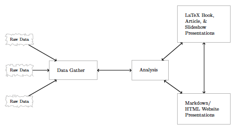

## Dicas

1. Documente tudo!
2. Tudo é um arquivo (de texto).
3. Todos os arquivos devem ser legíveis (por humanos).
4. Relacione explicitamente seus arquivos.
5. Tenha um plano para organizar, armazenar e disponibilizar seus arquivos.

## Versionando projetos

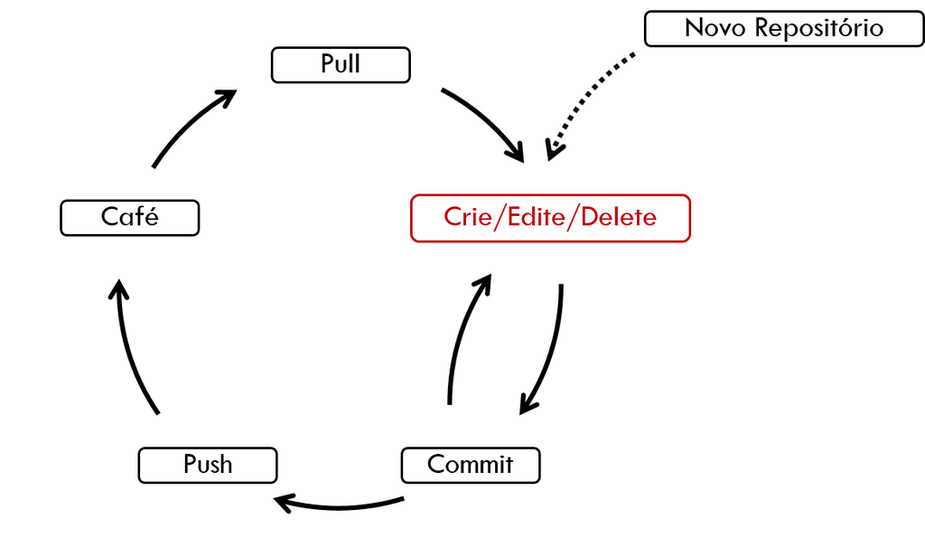

## Repositório: Criação de repositório do projeto no Github

[figure not shown]

## .Rproj: Criação do Projeto no RStudio

[figure not shown]

## Commit: Editando e “Commitando” as mudanças no código

[figure not shown]

## Push: Subindo os commits para o Github

[figure not shown]

## Pull: Baixando o estado atual do projeto

[figure not shown]

## ioslides no Rmarkdown

## Trabalhando com slides no RMarkdown

- Manual https://rmarkdown.rstudio.com/lesson-11.html
- Galeria https://rmarkdown.rstudio.com/gallery.html

File ==> New file ==> R Markdown ==> Presentation

- HTML (ioslides)

## Trabalhando no .rmd

- Opções e detalhes do ioslides https://rmarkdown.rstudio.com/ioslides_presentation_format#overview
- Mais referências https://bookdown.org/yihui/rmarkdown/ioslides-presentation.html
- Montando o arquivo `ìndex.rmd`

## Gerenciamento de arquivos